# Week 11 - Correlation, simple & multiple regression

### Setup details

- This lecture use the following scripts, assumed to be in your course scripts directory.
  - `COURSE/scripts/viridis.R`
- You also need the following data sets
  - `COURSE/data/lions.csv`
  - `COURSE/data/riley.csv`
  - `../../data/TIM.txt`
- You will need the package **tidyverse** for these lectures.

# Introduction to Correlation

## Lion Ages

- Biologists are interested in examining the relationship between the age of lions and the proportion of their nose that is black.
- Data are collected from a group of lions whose ages are known.
- The hope is to develop a model to predict the age of lions with unknown age from something that can be measured from a distance with minimal interference from an image of the lion’s face.
- Experts use multiple characteristics in addition to nose color, such as mane length, teeth wear, and facial scarring.

### Data

```r
lions = read_csv("../../data/lions.csv") %>%
  rename(black = proportion.black)
```

```
## Error: '../../data/lions.csv' does not exist in current working directory ('C:/Users/cblin/Documents/STAT240/lecture/week 11').
```

### Numerical Summary

- Calculate:
  - the number of cases;
  - means and standard deviations of each variable;
  - the correlation (more on this below)

```r
## first few rows
head(lions)
```

```
## Error in eval(expr, envir, enclos): object 'lions' not found
```

```r
lions_sum = lions %>%
  summarize(across(everything(), list(mean = mean, sd = sd)),
            n = n(),
            r = cor(age, black)) %>%
  relocate(n)
```

```
## Error in eval(expr, envir, enclos): object 'lions' not found
```

```r
lions_sum
```

```
## Error in eval(expr, envir, enclos): object 'lions_sum' not found
```

### Graphical Summary

- We use a scatter plot to show the relationship between these variables
- Add a simple linear regression line with `geom_smooth()`.

```r
ggplot(lions, aes(x = age, y = black)) +
  geom_point() +
  xlab("Age (years)") +
  ylab("Percentage Black") +
  scale_y_continuous(labels = scales::percent) +
  ggtitle("Ages and Lion Nose Color") +
  geom_smooth(se = FALSE, method = "lm") +
  theme_bw() +
  theme(text = element_text(size = 20))
```

```
## Error in eval(expr, envir, enclos): object 'lions' not found
```

## The Correlation Coefficient r

- The *correlation coefficient* `r` is a measure of the strength of a linear relationship between two quantitative variables.
- The formula is

$$r = \mathsf{Corr}(x,y) = \frac{1}{n-1}\sum_{i=1}^n
\left(\frac{x_i - \bar{x}}{s_x} \right)
\left(\frac{y_i - \bar{y}}{s_y} \right)$$

- From the equation, note that:
  - $\mathsf{Corr}(x,y) = \mathsf{Corr}(y,x)$
    - The order of the variables does not matter
  - The individual values of $x$ and $y$ are standardized by subtracting the mean and dividing by the standard deviation (z scores)
  - $r$ is the average of the product of these standardized values
    - The $n-1$ in the denominator is because sample standard deviations $s_x$ and $s_y$ use $n-1$.
    - If we instead used the population standard deviation formula with $n$ and not $n-1$, then there would be a leading $1/n$ and not $1/(n-1)$
  - $r$ is unitless
    - Any units in $x$ and $y$ are eliminated in standardization
    - Changing the scale of measurement of $x$ and/or $y$ does not change $r$
  - For cases where $x$ and $y$ are both greater than their mean or less than their mean, the sum gets bigger as the product is positive
  - For cases where one of $x$ and $y$ is greater than its mean and the other is less than it mean, the product is negative and the sum is made smaller
- Not obvious from the equation, but provable with a mathematical argument is that $-1 \le r \le 1$.
- $r = 1$ if and only if the points fall exactly on a line with a positive slope
- $r = -1$ if and only if the points fall exactly on a line with a negative slope

```r
ggplot(lions, aes(x = age, y = black)) +
  geom_point() +
  xlab("Age (years)") +
  ylab("Percentage Black") +
  scale_y_continuous(labels = scales::percent) +
  ggtitle("Ages and Lion Nose Color",
          subtitle = "Red dashed lines at variable means") +
  geom_vline(xintercept = lions_sum$age_mean, color = "red", linetype = "dashed") +
  geom_hline(yintercept = lions_sum$black_mean, color = "red", linetype = "dashed") +
  theme_bw() +
  theme(text = element_text(size = 20))
```

```
## Error in eval(expr, envir, enclos): object 'lions' not found
```

### Calculation

- The built-in R function `cor()` calculate the correlation coefficient.

```r
x = lions %>% pull(age)
```

```
## Error in eval(expr, envir, enclos): object 'lions' not found
```

```r
y = lions %>% pull(black)
```

```
## Error in eval(expr, envir, enclos): object 'lions' not found
```

```r
cor(x,y)
```

```
## Error in eval(expr, envir, enclos): object 'y' not found
```

- Demonstrate with a manual calculation

```r
lions_calc = lions %>%
  mutate(z_age = (age - mean(age))/sd(age),
         z_black = (black - mean(black))/sd(black),
         prod = z_age * z_black)
```

```
## Error in eval(expr, envir, enclos): object 'lions' not found
```

```r
lions_calc %>%
  print(n = Inf)
```

```
## Error in eval(expr, envir, enclos): object 'lions_calc' not found
```

```r
lions_calc %>%
  summarize(r = sum(prod) / (n() - 1)) %>%
  pull(r)
```

```
## Error in eval(expr, envir, enclos): object 'lions_calc' not found
```

### Fake Data Examples

#### r near 0

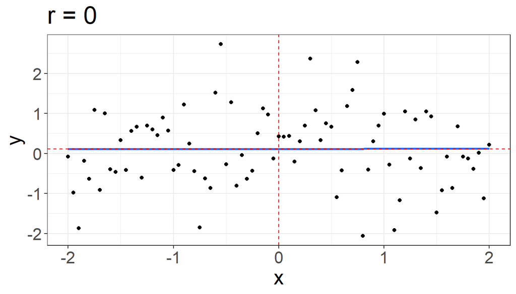

- There is no apparent pattern in the relationship between $x$ and $y$.
- $r$ is quite close to 0.

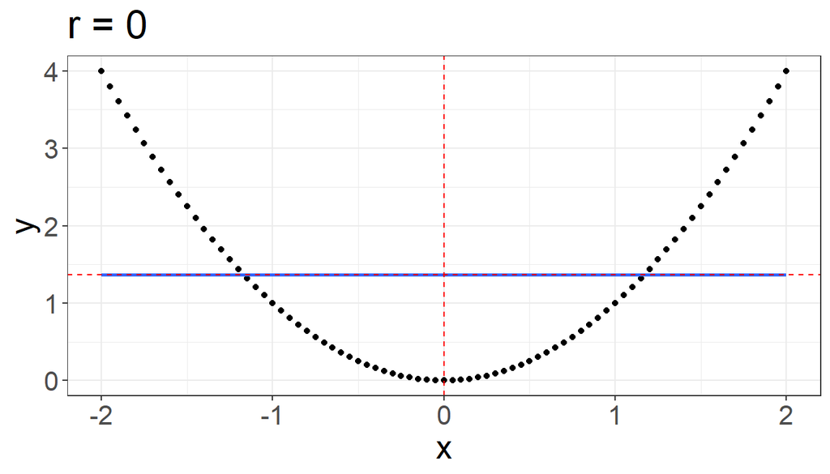

- There is a deterministic non-linear relationship between $x$ and $y$
- $r = 0$

> When $r=0$, there is a weak linear relationship between $x$ and $y$. There may or may not be a strong non-linear relationship between $x$ and $y$.

#### r near 1

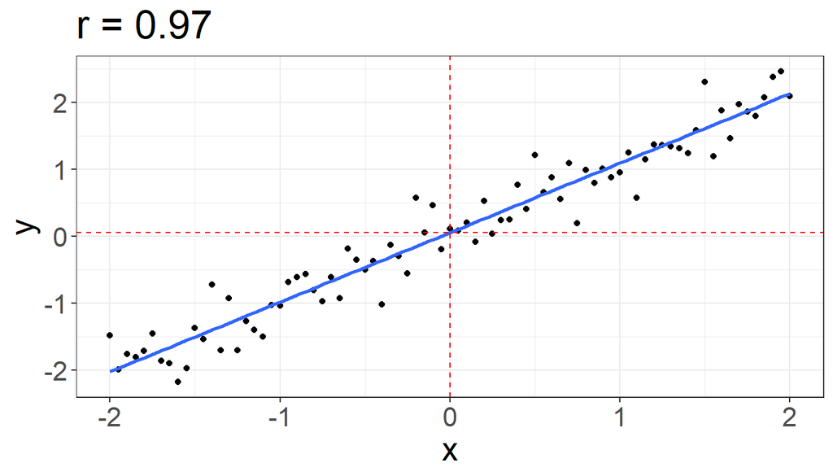

- $r$ is near 1
- The points are tightly clustered around a line with a positive slope
- It does not appear that a curve would fit the trend in the data substantially better.

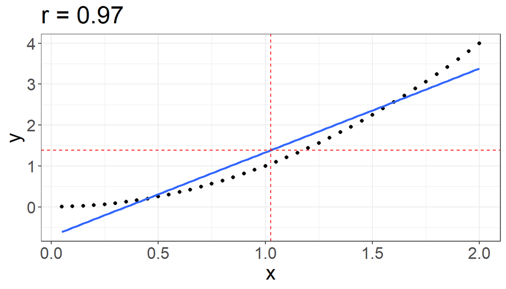

- $r$ near one
- The points are much more tightly clustered around the blue line with a positive slope than around the horizontal red dashed line
- However, a curve would fit the data substantially better than a straight line
- A non-linear relationship is superior to a simpler linear relationship

> When $r = 0.97$ there is a strong positive linear relationship between $x$ and $y$. There may or may not be an even stronger non-linear relationship between $x$ and $y$.

#### r near $-1$

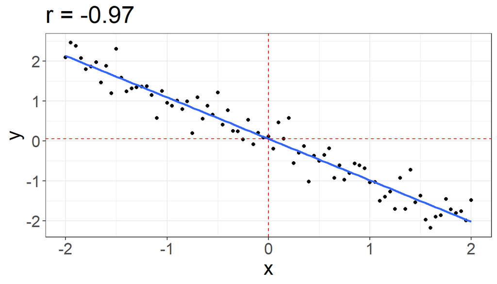

- $r$ is near $-1$
- The points are tightly clustered around a line with a negative slope
- It does not appear that a curve would fit the trend in the data substantially better.

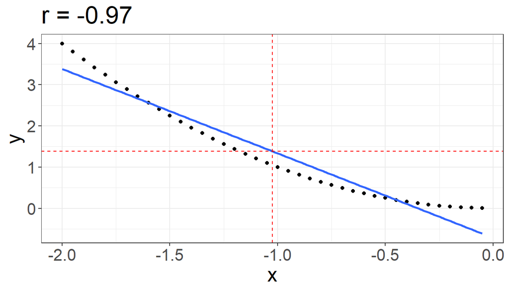

- $r$ is near $-1$
- The points are more tightly clustered around the blue line with a negative slope than around the horizontal red dashed line.
- However, a non-linear relationship is superior to a simpler linear relationship.

> When $r = -0.97$, there is a strong negative linear relationship between $x$ and $y$ There may or may not be an even stronger non-linear relationship between $x$ and $y$.

#### r near 0.7

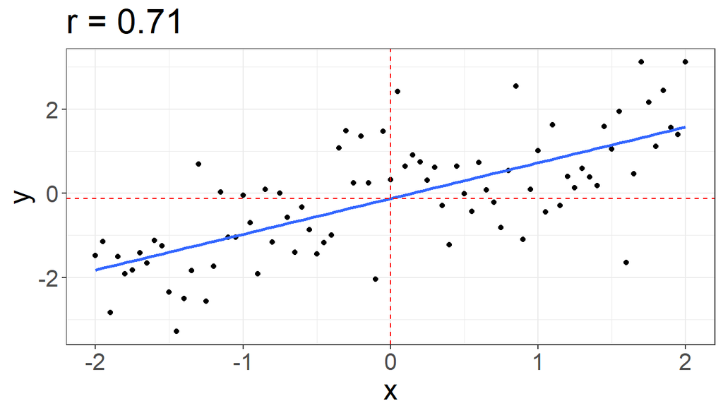

- $r$ is moderate and positive
- the points are more tightly clustered around the blue line with a positive slope than around the horizontal red dashed line
- the strength of the linear relationship is moderate
- a simpler linear relationship is an adequate summary of the data
  - there is no non-linear relationship that is a substantially better fit to the data

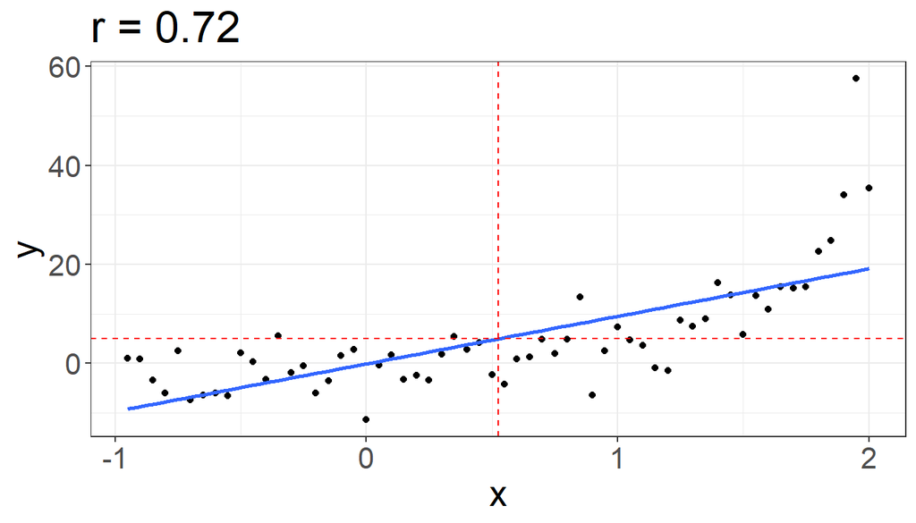

- $r$ is moderate and positive
- the points are more tightly clustered around the blue line with a positive slope than around the horizontal red dashed line, but only by a smallish amount
- the strength of the linear relationship is moderate
- a non-linear linear relationship would fit the data better than a simple line

> When $r$ is near 0.7, there is a moderate positive linear relationship between $x$ and $y$. There may or may not be a nonlinear relationship which fits the data substantially better

### Thought Quiz

1. Why is there no distinction between the explanatory and response variables in correlation?
2. Why do both variables have to be quantitative?
3. How does changing the units of measurement change correlation?
4. Why doesn’t a tight fit to a horizontal line imply strong correlation?

### Correlation summary

- $r$ is a measure of the strength and direction of the **linear** relationship between two quantitative variables
- The value of $r$ alone says nothing about the strength of any potential non-linear relationships
- Graph your data!

# Introduction to Regression

## Background

- Many problems in Statistics and Data Science involve examining the relationship between variables.
- A common setting is when:
  - a single quantitative variable is deemed a *response variable*
  - one or more other variables are treated as *explanatory variables* or *predictors*.
- Such models are referred to as *linear models*
  - In a standard linear model, the response variable is assumed to have a normal distribution given the predictors.

### Special cases

- Linear models can be categorized based on the number and types of the predictors.
  - *simple linear regression*: a single quantitative predictor
  - *multiple regression*: multiple quantitative predictors
  - *one-way analysis of variance*: a single categorical predictor
  - *analysis of variance*: multiple categorical predictors

### Generalizations

- When the distribution of the response variable is not modeled with a normal distribution, such as when it is a count or a single 0/1 response, it is often preferable to use a *generalized linear model*.
  - *logistic regression*: for 0/1 response variables;
  - *Poisson regression*: for non-negative count data.
- At other times, it is preferable to model a categorical predictor as having a distribution itself. Some of these models are called *mixed effects models*.

### Summary of the regression line

Correlation tells us about the strength and direction of a line.

- What if we want a description of how the variables vary together?

The regression line…

- A regression line is a straight line that describes how a response variable y changes as an explanatory variable x changes
- We can use a regression line to predict the value of y for a given value of x
- The distinction between explanatory and response variables is important
- The Least-squares regression line is the unique line such that the sum of the squared vertical (y) distances between the data points and the line is as small as possible.

## Example: Age and Height

```r
riley = read_table("../../data/riley.txt")
```

```
## Error: '../../data/riley.txt' does not exist in current working directory ('C:/Users/cblin/Documents/STAT240/lecture/week 11').
```

```r
df = riley %>%
  filter(age >=2*12 & age <=8*12)
```

```
## Error in eval(expr, envir, enclos): object 'riley' not found
```

```r
ggplot(df, aes(x = age, y = height)) +
  geom_point() +
  geom_smooth(se = FALSE, method = "lm") +
  ylab("Height (inches)") +
  xlab("Age (months)")
```

```
## Error in `ggplot()`:
## ! `data` cannot be a function.
## ℹ Have you misspelled the `data` argument in `ggplot()`
```

## Regression Model

$$Y_i = \beta_0 + \beta_1 X_i + \varepsilon_i$$

- $Y_i$ is the response variable
- $X_i$ is the explanatory variable
- $\beta_0$ is the intercept
- $\beta_1$ is the slope
- $\varepsilon_i$ is the random “error” between the actual value $Y_i$ and the mean value $\beta_0 + \beta_1 X_i$.
- A common method to estimate $\beta_0$ and $\beta_1$ from data $x$ and $y$ is the method of “least squares”
  - This line minimizes the sum of squared vertical distances between the points and a line
  - Find values $\hat{\beta}_0$ and $\hat{\beta}_1$ to minimize

$$\sum_{i=1}^n \big(y_i - (\beta_0 + \beta_1 x_i)\big)^2$$

- There is a multivariate calculus solution to this problem, but we explore a different way to do it.

### lm()

- We can use `lm()` to fit the linear regression model

```r
df_lm = lm(height ~ age, data = df)
```

```
## Error in model.frame.default(formula = height ~ age, data = df, drop.unused.levels = TRUE): 'data' must be a data.frame, environment, or list
```

```r
cf = coef(df_lm)
```

```
## Error in eval(expr, envir, enclos): object 'df_lm' not found
```

```r
cf
```

```
## Error in eval(expr, envir, enclos): object 'cf' not found
```

```r
summary(df_lm)
```

```
## Error in eval(expr, envir, enclos): object 'df_lm' not found
```

### Coefficients and Summary Statistics

- The least squares coefficients have simple equations based on summary statistics of the data.

$$\hat{\beta}_1 = r \times \frac{s_y}{s_x}$$

$$\hat{\beta}_0 = \bar{y} - \hat{\beta}_1 \bar{x}$$

- Note that the regression line goes through the point $(\bar{x},\bar{y})$.

```r
x = df$age
```

```
## Error in df$age: object of type 'closure' is not subsettable
```

```r
y = df$height
```

```
## Error in df$height: object of type 'closure' is not subsettable
```

```r
xbar = mean(x)
```

```
## Error in eval(expr, envir, enclos): object 'x' not found
```

```r
ybar = mean(y)
```

```
## Error in eval(expr, envir, enclos): object 'y' not found
```

```r
sx = sd(x)
```

```
## Error in eval(expr, envir, enclos): object 'x' not found
```

```r
sy = sd(y)
```

```
## Error in eval(expr, envir, enclos): object 'y' not found
```

```r
r = cor(x,y)
```

```
## Error in eval(expr, envir, enclos): object 'y' not found
```

```r
c(xbar, ybar, sx, sy, r)
```

```
## Error in eval(expr, envir, enclos): object 'xbar' not found
```

```r
b1 = r *sy/sx
```

```
## Error in eval(expr, envir, enclos): object 'r' not found
```

```r
b0 = ybar - b1*xbar
```

```
## Error in eval(expr, envir, enclos): object 'ybar' not found
```

```r
c(b0, b1)
```

```
## Error in eval(expr, envir, enclos): object 'b0' not found
```

```r
cf
```

```
## Error in eval(expr, envir, enclos): object 'cf' not found
```

### Estimated model

Using observations $(x_1,y_1), \ldots, (x_n,y_n)$, we can estimate $\beta_0$ and $\beta_1$ to get our Least-squares regression line as

$$\hat{y}_i = \hat{\beta}_0 + \hat{\beta}_1 x_i,$$
where $\hat{y}_i$ is the predicted response corresponding to $x_i$, and $\hat{\beta}_0$ and $\hat{\beta}_1$ are the estimated intercept and slope, respectively.

Least-squares Estimation: minimize the squared errors with respect to the unknown parameters.
- This is accomplished by minimizing the following with respect to the unknown parameters:
$$\sum_{i=1}^n(y_i - \hat{y}_i)^2 = \sum_{i=1}^n(y_i - (\hat{\beta}_0 +
\hat{\beta}_1 x_i))^2$$
- This results in the estimators noted above for $\beta_0$ and $\beta_1$.

### Predicted values

- The straightforward way to make a prediction is just to plug into the regression equation with the estimated coefficients.
- Estimate the boy’s height at age 50 months.

```r
## one way
est = b0 + 50*b1
```

```
## Error in eval(expr, envir, enclos): object 'b0' not found
```

```r
est
```

```
## Error in eval(expr, envir, enclos): object 'est' not found
```

```r
## using coef()
sum(cf * c(1,50))
```

```
## Error in eval(expr, envir, enclos): object 'cf' not found
```

```r
## Visualization of this prediction
ggplot(df, aes(x = age, y = height)) +
  geom_point() +
  geom_smooth(se = FALSE, method = "lm") +
  geom_point(aes(x=50, y=b0 + 50*b1), color="red", size=4) +
  geom_vline(xintercept = 50, color="red", linetype="dashed") +
  ylab("Height (inches)") +
  xlab("Age (months)")
```

```
## Error in `ggplot()`:
## ! `data` cannot be a function.
## ℹ Have you misspelled the `data` argument in `ggplot()`
```

#### Understand by standard units

- We can also understand this with standard units.
- The value $x=50$ is $z = (50 - \bar{x})/s_x)$ standard deviations from the mean.

```r
x0 = 50
z = (x0 - mean(x))/sd(x)
```

```
## Error in eval(expr, envir, enclos): object 'x' not found
```

```r
z
```

```
## Error in eval(expr, envir, enclos): object 'z' not found
```

- We predict that $y$ will be $rz$ standard deviations from $\bar{y}$.
  - Here, $r$ is very close to one, so we predict that $y$ is nearly the same number of standard deviations from $\bar{y}$ as $x$ was from $\bar{x}$.

```r
yhat = mean(y) + r*z*sd(y)
```

```
## Error in eval(expr, envir, enclos): object 'y' not found
```

```r
yhat
```

```
## Error in eval(expr, envir, enclos): object 'yhat' not found
```

### Lion Data

- Let’s try this with the lions data

```r
lions = read_csv("../../data/lions.csv") %>%
  rename(black = proportion.black)
```

```
## Error: '../../data/lions.csv' does not exist in current working directory ('C:/Users/cblin/Documents/STAT240/lecture/week 11').
```

```r
ggplot(lions, aes(x = age, y = black)) +
  geom_point() +
  geom_smooth(se = FALSE, method = "lm") +
  xlab("Age (years)") +
  ylab("Proportion of nose that is black")
```

```
## Error in eval(expr, envir, enclos): object 'lions' not found
```

```r
lions_lm = lm(black ~ age, data = lions)
```

```
## Error in eval(mf, parent.frame()): object 'lions' not found
```

```r
lions_cf = coef(lions_lm)
```

```
## Error in eval(expr, envir, enclos): object 'lions_lm' not found
```

```r
lions_cf
```

```
## Error in eval(expr, envir, enclos): object 'lions_cf' not found
```

```r
summary(lions_lm)
```

```
## Error in eval(expr, envir, enclos): object 'lions_lm' not found
```

#### Summary Statistics

```r
lions_sum = lions %>%
  summarize(across(everything(), list(mean = mean, sd = sd)),
            n = n(),
            r = cor(age, black)) %>%
  relocate(n)
```

```
## Error in eval(expr, envir, enclos): object 'lions' not found
```

```r
lions_sum = lions_sum %>%
  mutate(b1 = r*black_sd/age_sd,
         b0 = black_mean - b1*age_mean)
```

```
## Error in eval(expr, envir, enclos): object 'lions_sum' not found
```

```r
lions_sum %>%
  print(width = Inf)
```

```
## Error in eval(expr, envir, enclos): object 'lions_sum' not found
```

- Predict at age 10 years

```r
yhat_1 = sum( c(1,10) * lions_cf )
```

```
## Error in eval(expr, envir, enclos): object 'lions_cf' not found
```

```r
yhat_1
```

```
## Error in eval(expr, envir, enclos): object 'yhat_1' not found
```

#### Standard Units

```r
x0 = 10
z = (x0 - lions_sum$age_mean)/lions_sum$age_sd
```

```
## Error in eval(expr, envir, enclos): object 'lions_sum' not found
```

```r
z
```

```
## Error in eval(expr, envir, enclos): object 'z' not found
```

```r
lions_sum$r*z
```

```
## Error in eval(expr, envir, enclos): object 'lions_sum' not found
```

```r
yhat_2 = lions_sum$black_mean + lions_sum$r*z*lions_sum$black_sd
```

```
## Error in eval(expr, envir, enclos): object 'lions_sum' not found
```

```r
yhat_2
```

```
## Error in eval(expr, envir, enclos): object 'yhat_2' not found
```

## Regression Example with fake data

We are going to generate a fake data set to use for our example. By using fake data, we can also check how close our regression estimates match the true values we used to simulate our data.

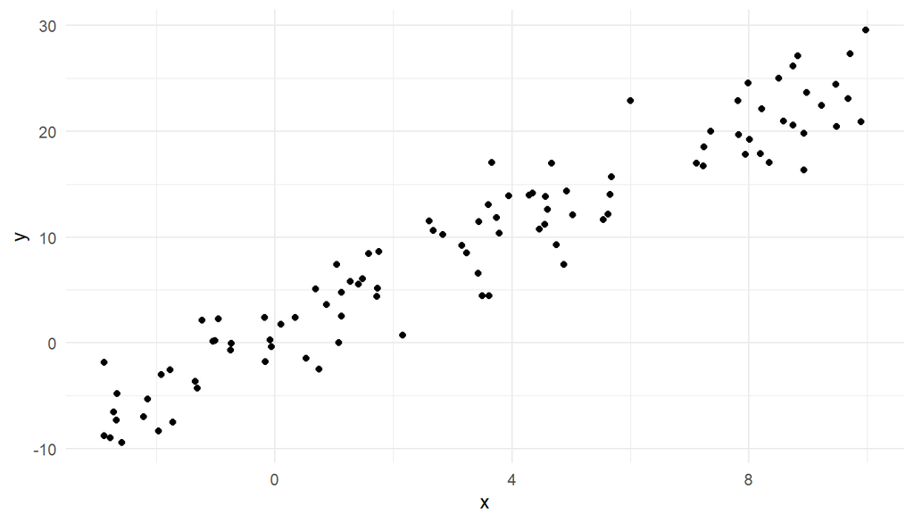

```r
## Generate our fake data set
set.seed(246810)
n <- 100 ## sample size
b0 <- 1  ## intercept
b1 <- 2.5  ## slope
x <- runif(n, -3, 10)  ## explanatory variable
y <- rnorm(n,b0+b1*x,3)  ## response variable

tibble(x,y) %>%
  ggplot(aes(x = x, y = y)) +
  geom_point()
```

```r
## Estimate our slope and intercept
mx <- mean(x)
my <- mean(y)
sx <- sd(x)
sy <- sd(y)

r <- cor(x,y) # correlation coef
r
```

```
## [1] 0.9567482
```

```r
cor(x,y)
```

```
## [1] 0.9567482
```

```r
cor(y,x)
```

```
## [1] 0.9567482
```

```r
b1_hat <- r *sy/sx
b1_hat
```

```
## [1] 2.462811
```

```r
b0_hat <- my - b1_hat*mx
b0_hat
```

```
## [1] 0.8643708
```

We also can use `lm()` to estimate the slope and intercept:

```r
df0 <- tibble(x=x, y=y)
lm0 <- lm(y~x, df0)
summary(lm0)
```

```
##
## Call:
## lm(formula = y ~ x, data = df0)
##
## Residuals:
##     Min      1Q  Median      3Q     Max
## -6.5064 -2.0083  0.2062  1.9766  7.2757
##
## Coefficients:
##             Estimate Std. Error t value Pr(>|t|)
## (Intercept)  0.86437    0.39085   2.211   0.0293 *
## x            2.46281    0.07565  32.557   <2e-16 ***
## ---
## Signif. codes:  0 '***' 0.001 '**' 0.01 '*' 0.05 '.' 0.1 ' ' 1
##
## Residual standard error: 2.951 on 98 degrees of freedom
## Multiple R-squared:  0.9154, Adjusted R-squared:  0.9145
## F-statistic:  1060 on 1 and 98 DF,  p-value: < 2.2e-16
```

```r
cf <- coef(lm0)
cf
```

```
## (Intercept)           x
##   0.8643708   2.4628111
```

```r
c(b0, b1)
```

```
## [1] 1.0 2.5
```

### Residual plots

One approach for checking if our linear assumption holds is to create a residual plot. Recall that residual corresponding to the $i$th observation is $r_i = y_i - \hat{y}_i$.

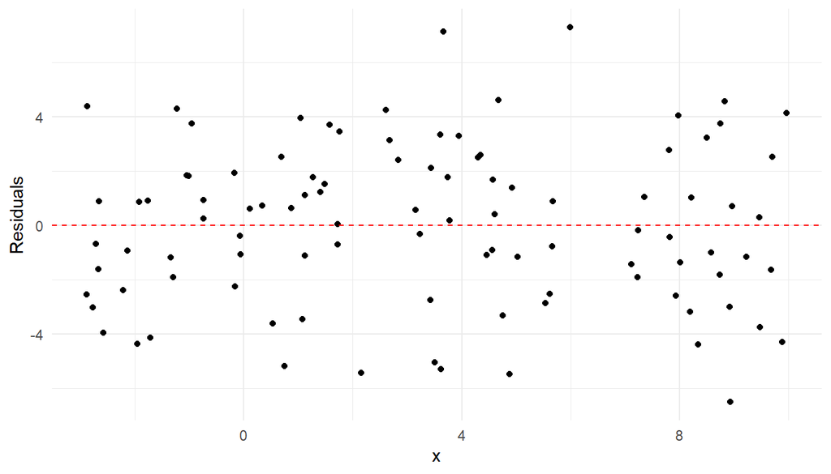

```r
library(modelr)
df0 <- df0 %>%
  add_residuals(lm0) %>%
  add_predictions(lm0)

ggplot(df0, aes(x=x, y =resid)) +
  geom_point() +
  xlab("x") +
  ylab("Residuals") +
  geom_hline(aes(yintercept=0), color="red", linetype = "dashed")
```

As a comparison, below is a residual plot for a different simulated data set.

Do you see any pattern in this residual plot?

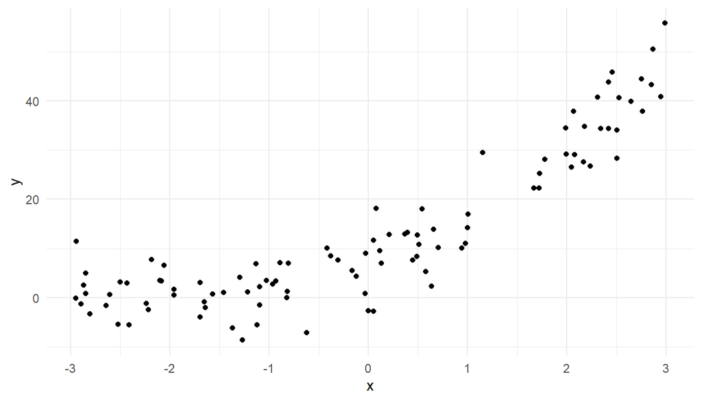

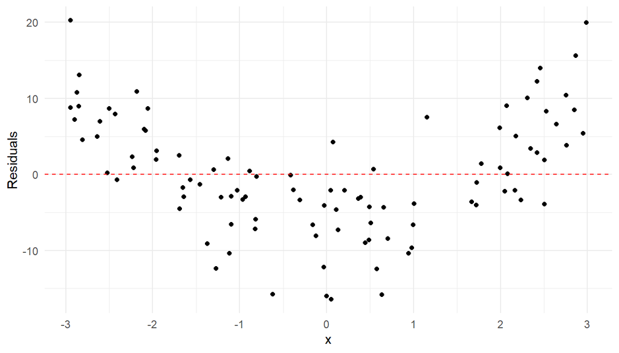

There is a clear pattern. The residuals near the boundaries are positive and the residuals near the middle of the x range are negative.

This suggests that the relationship between y and x is not linear and appears to be quadratic.

# Introduction to Regression

## Background

- Many problems in Statistics and Data Science involve examining the relationship between variables.
- A common setting is when:
  - a single quantitative variable is deemed a *response variable*
  - one or more other variables are treated as *explanatory variables* or *predictors*.
- Such models are referred to as *linear models*
  - In a standard linear model, the response variable is assumed to have a normal distribution given the predictors.

### Special cases

- Linear models can be categorized based on the number and types of the predictors.
  - *simple linear regression*: a single quantitative predictor
  - *multiple regression*: multiple quantitative predictors
  - *one-way analysis of variance*: a single categorical predictor
  - *analysis of variance*: multiple categorical predictors

### Generalizations

- When the distribution of the response variable is not modeled with a normal distribution, such as when it is a count or a single 0/1 response, it is often preferable to use a *generalized linear model*.
  - *logistic regression*: for 0/1 response variables;
  - *Poisson regression*: for non-negative count data.
- At other times, it is preferable to model a categorical predictor as having a distribution itself. Some of these models are called *mixed effects models*.

### Summary of the regression line

Correlation tells us about the strength and direction of a line.

- What if we want a description of how the variables vary together?

The regression line…

- A regression line is a straight line that describes how a response variable y changes as an explanatory variable x changes
- We can use a regression line to predict the value of y for a given value of x
- The distinction between explanatory and response variables is important
- The Least-squares regression line is the unique line such that the sum of the squared vertical (y) distances between the data points and the line is as small as possible.

## Example: Age and Height

```r
riley = read_table("../../data/riley.txt")
```

```
## Error: '../../data/riley.txt' does not exist in current working directory ('C:/Users/cblin/Documents/STAT240/lecture/week 11').
```

```r
df = riley %>%
  filter(age >=2*12 & age <=8*12)
```

```
## Error in eval(expr, envir, enclos): object 'riley' not found
```

```r
ggplot(df, aes(x = age, y = height)) +
  geom_point() +
  geom_smooth(se = FALSE, method = "lm") +
  ylab("Height (inches)") +
  xlab("Age (months)")
```

```
## Error in `ggplot()`:
## ! `data` cannot be a function.
## ℹ Have you misspelled the `data` argument in `ggplot()`
```

## Regression Model

$$Y_i = \beta_0 + \beta_1 X_i + \varepsilon_i$$

- $Y_i$ is the response variable
- $X_i$ is the exoplantory variable
- $\beta_0$ is the intercept
- $\beta_1$ is the slope
- $\varepsilon_i$ is the random “error” between the actual value $Y_i$ and the mean value $\beta_0 + \beta_1 X_i$.
- A common method to estimate $\beta_0$ and $\beta_1$ from data $x$ and $y$ is the method of “least squares”
  - This line minimizes the sum of squared vertical distances between the points and a line
  - Find values $\hat{\beta}_0$ and $\hat{\beta}_1$ to minimize

$$\sum_{i=1}^n \big(y_i - (\beta_0 + \beta_1 x_i)\big)^2$$

- There is a multivariate calculus solution to this problem, but we explore a different way to do it.

### lm()

- We can use `lm()` to fit the linear regression model

```r
df_lm = lm(height ~ age, data = df)
```

```
## Error in model.frame.default(formula = height ~ age, data = df, drop.unused.levels = TRUE): 'data' must be a data.frame, environment, or list
```

```r
cf = coef(df_lm)
```

```
## Error in eval(expr, envir, enclos): object 'df_lm' not found
```

```r
cf
```

```
## (Intercept)           x
##   0.8643708   2.4628111
```

```r
summary(df_lm)
```

```
## Error in eval(expr, envir, enclos): object 'df_lm' not found
```

### Coefficients and Summary Statistics

- The least squares coefficients have simple equations based on summary statistics of the data.

$$\hat{\beta}_1 = r \times \frac{s_y}{s_x}$$

$$\hat{\beta}_0 = \bar{y} - b_1 \bar{x}$$

- Note that the regression line goes through the point $(\bar{x},\bar{y})$.

```r
x = df$age
```

```
## Error in df$age: object of type 'closure' is not subsettable
```

```r
y = df$height
```

```
## Error in df$height: object of type 'closure' is not subsettable
```

```r
xbar = mean(x)
ybar = mean(y)
sx = sd(x)
sy = sd(y)
r = cor(x,y)

c(xbar, ybar, sx, sy, r)
```

```
## [1]  3.3878224  9.2079375  3.9207946 10.0927039  0.9567482
```

```r
b1 = r *sy/sx
b0 = ybar - b1*xbar

c(b0, b1)
```

```
## [1] 0.8643708 2.4628111
```

```r
cf
```

```
## (Intercept)           x
##   0.8643708   2.4628111
```

### Estimated model

Using observations $(x_1,y_1), \ldots, (x_n,y_n)$, we can estimate $\beta_0$ and $\beta_1$ to get our Least-squares regression line as

$$\hat{y}_i = \hat{\beta}_0 + \hat{\beta}_1 x_i,$$
where $\hat{y}_i$ is the predicted response corresponding to $x_i$, and $\hat{\beta}_0$ and $\hat{\beta}_1$ are the estimated intercept and slope, respectively.

Least-squares Estimation: minimize the squared errors with respect to the unknown parameters.
- This is accomplished by minimizing the following with respect to the unknown parameters:
$$\sum_{i=1}^n(y_i - \hat{y}_i)^2 = \sum_{i=1}^n(y_i - (\hat{\beta}_0 +
\hat{\beta}_1 x_i))^2$$
- This results in the estimators noted above for $\beta_0$ and $\beta_1$.

### Predicted values

- The straightforward way to make a prediction is just to plug into the regression equation with the estimated coefficients.
- Estimate the boy’s height at age 50 months.

```r
## one way
est = b0 + 50*b1
est
```

```
## [1] 124.0049
```

```r
## using coef()
sum(cf * c(1,50))
```

```
## [1] 124.0049
```

```r
## Visualization of this prediction
ggplot(df, aes(x = age, y = height)) +
  geom_point() +
  geom_smooth(se = FALSE, method = "lm") +
  geom_point(aes(x=50, y=b0 + 50*b1), color="red", size=4) +
  geom_vline(xintercept = 50, color="red", linetype="dashed") +
  ylab("Height (inches)") +
  xlab("Age (months)")
```

```
## Error in `ggplot()`:
## ! `data` cannot be a function.
## ℹ Have you misspelled the `data` argument in `ggplot()`
```

#### Understand by standard units

- We can also understand this with standard units.
- The value $x=50$ is $z = (50 - \bar{x})/s_x)$ standard deviations from the mean.

```r
x0 = 50
z = (x0 - mean(x))/sd(x)
z
```

```
## [1] 11.88845
```

- We predict that $y$ will be $rz$ standard deviations from $\bar{y}$.
  - Here, $r$ is very close to one, so we predict that $y$ is nearly the same number of standard deviations from $\bar{y}$ as $x$ was from $\bar{x}$.

```r
yhat = mean(y) + r*z*sd(y)
yhat
```

```
## [1] 124.0049
```

### Lion Data

- Let’s try this with the lions data

```r
lions = read_csv("../../data/lions.csv") %>%
  rename(black = proportion.black)
```

```
## Error: '../../data/lions.csv' does not exist in current working directory ('C:/Users/cblin/Documents/STAT240/lecture/week 11').
```

```r
ggplot(lions, aes(x = age, y = black)) +
  geom_point() +
  geom_smooth(se = FALSE, method = "lm") +
  xlab("Age (years)") +
  ylab("Proportion of nose that is black")
```

```
## Error in eval(expr, envir, enclos): object 'lions' not found
```

```r
lions_lm = lm(black ~ age, data = lions)
```

```
## Error in eval(mf, parent.frame()): object 'lions' not found
```

```r
lions_cf = coef(lions_lm)
```

```
## Error in eval(expr, envir, enclos): object 'lions_lm' not found
```

```r
lions_cf
```

```
## Error in eval(expr, envir, enclos): object 'lions_cf' not found
```

```r
summary(lions_lm)
```

```
## Error in eval(expr, envir, enclos): object 'lions_lm' not found
```

#### Summary Statistics

```r
lions_sum = lions %>%
  summarize(across(everything(), list(mean = mean, sd = sd)),
            n = n(),
            r = cor(age, black)) %>%
  relocate(n)
```

```
## Error in eval(expr, envir, enclos): object 'lions' not found
```

```r
lions_sum = lions_sum %>%
  mutate(b1 = r*black_sd/age_sd,
         b0 = black_mean - b1*age_mean)
```

```
## Error in eval(expr, envir, enclos): object 'lions_sum' not found
```

```r
lions_sum %>%
  print(width = Inf)
```

```
## Error in eval(expr, envir, enclos): object 'lions_sum' not found
```

- Predict at age 10 years

```r
yhat_1 = sum( c(1,10) * lions_cf )
```

```
## Error in eval(expr, envir, enclos): object 'lions_cf' not found
```

```r
yhat_1
```

```
## Error in eval(expr, envir, enclos): object 'yhat_1' not found
```

#### Standard Units

```r
x0 = 10
z = (x0 - lions_sum$age_mean)/lions_sum$age_sd
```

```
## Error in eval(expr, envir, enclos): object 'lions_sum' not found
```

```r
z
```

```
## [1] 11.88845
```

```r
lions_sum$r*z
```

```
## Error in eval(expr, envir, enclos): object 'lions_sum' not found
```

```r
yhat_2 = lions_sum$black_mean + lions_sum$r*z*lions_sum$black_sd
```

```
## Error in eval(expr, envir, enclos): object 'lions_sum' not found
```

```r
yhat_2
```

```
## Error in eval(expr, envir, enclos): object 'yhat_2' not found
```

## Regression Example with fake data

We are going to generate a fake data set to use for our example. By using fake data, we can also check how close our regression estimates match the true values we used to simulate our data.

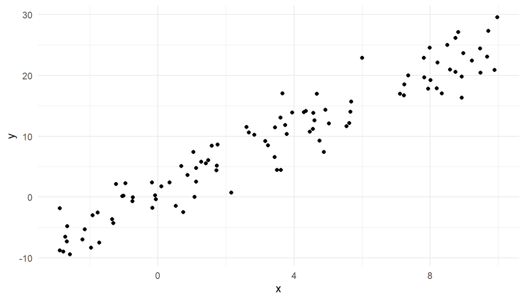

```r
## Generate our fake data set
set.seed(246810)
n <- 100 ## sample size
b0 <- 1  ## intercept
b1 <- 2.5  ## slope
x <- runif(n, -3, 10)  ## explanatory variable
y <- rnorm(n,b0+b1*x,3)  ## response variable

tibble(x,y) %>%
  ggplot(aes(x = x, y = y)) +
  geom_point()
```

```r
## Estimate our slope and intercept
mx <- mean(x)
my <- mean(y)
sx <- sd(x)
sy <- sd(y)

r <- cor(x,y) # correlation coef
r
```

```
## [1] 0.9567482
```

```r
cor(x,y)
```

```
## [1] 0.9567482
```

```r
cor(y,x)
```

```
## [1] 0.9567482
```

```r
b1_hat <- r *sy/sx
b1_hat
```

```
## [1] 2.462811
```

```r
b0_hat <- my - b1_hat*mx
b0_hat
```

```
## [1] 0.8643708
```

We also can use `lm()` to estimate the slope and intercept:

```r
df0 <- tibble(x=x, y=y)
lm0 <- lm(y~x, df0)
summary(lm0)
```

```
##
## Call:
## lm(formula = y ~ x, data = df0)
##
## Residuals:
##     Min      1Q  Median      3Q     Max
## -6.5064 -2.0083  0.2062  1.9766  7.2757
##
## Coefficients:
##             Estimate Std. Error t value Pr(>|t|)
## (Intercept)  0.86437    0.39085   2.211   0.0293 *
## x            2.46281    0.07565  32.557   <2e-16 ***
## ---
## Signif. codes:  0 '***' 0.001 '**' 0.01 '*' 0.05 '.' 0.1 ' ' 1
##
## Residual standard error: 2.951 on 98 degrees of freedom
## Multiple R-squared:  0.9154, Adjusted R-squared:  0.9145
## F-statistic:  1060 on 1 and 98 DF,  p-value: < 2.2e-16
```

```r
cf <- coef(lm0)
cf
```

```
## (Intercept)           x
##   0.8643708   2.4628111
```

```r
c(b0, b1)
```

```
## [1] 1.0 2.5
```

### Residual plots

One approach for checking if our linear assumption holds is to create a residual plot. Recall that residual corresponding to the $i$th observation is $r_i = y_i - \hat{y}_i$.

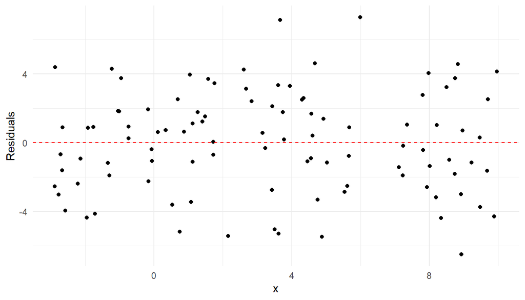

```r
library(modelr)
df0 <- df0 %>%
  add_residuals(lm0) %>%
  add_predictions(lm0)

ggplot(df0, aes(x=x, y =resid)) +
  geom_point() +
  xlab("x") +
  ylab("Residuals") +
  geom_hline(aes(yintercept=0), color="red", linetype = "dashed")
```

As a comparison, below is a residual plot for a different simulated data set.

Do you see any pattern in this residual plot?

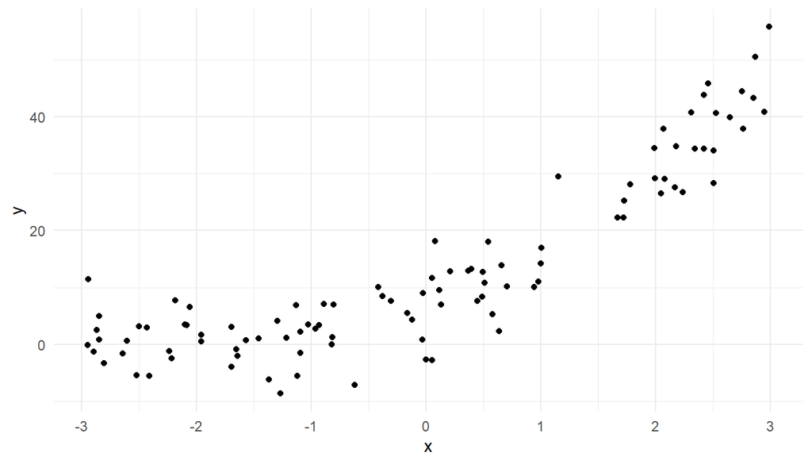

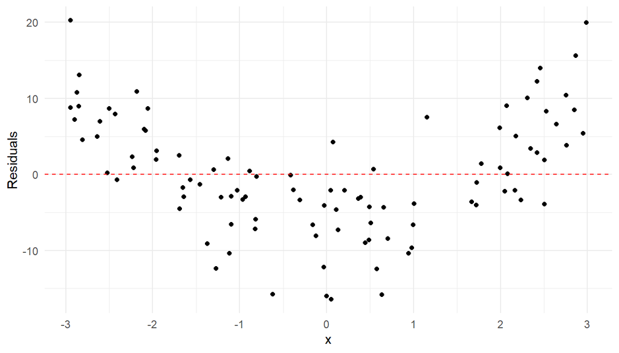

There is a clear pattern. The residuals near the boundaries are positive and the residuals near the middle of the x range are negative.

This suggests that the relationship between y and x is not linear and appears to be quadratic.

# Overview of Exoplanet Mass-Radius Relationship

In previous lectures, we explored data from the NASA Exoplanet Archive. Two variables that are useful for characterizing an exoplanet are mass and radius.

The two most prolific methods for detecting exoplanets are the Transit Method and the Radial Velocity Method.

- The Transit Method works by monitoring the total light output of a star across time.
  - If a planet crosses between the star in the line-of-sight of the telescope, we may observe a dip in the light output of the star.
  - A dip that repeats at a regular period suggests that a planet may be present.
  - Often at least three periodic dips are necessary for the detection to be considered credible.
  - Here is a YouTube video that illustrates the Transit Method: https://youtu.be/RrusIZaWDW8
  - The depth of the transit (i.e., the depth of the dip in the light output) can be used to estimate the planet’s radius relative to the host star.
- The Radial Velocity (RV) Method looks for a wobble in the star suggesting an object may be orbiting it.
  - The host star is observed on multiple nights (often 30 or more) and a spectrum is collected using a spectrograph each nights (sometimes multiple times in a night).
  - From the observed spectrum, some techniques are used to estimate how fast the star was moving toward or away from the observed at the time the observation was collect (i.e., the radial velocity is estimated).
  - The estimated radial velocities are plotted against time. If the points follow a particular pattern, it suggests the motion of the star may be due to a planet orbiting.
  - Here is a YouTube video that illustrates the RV Method: https://youtu.be/tUzDKlaTHFM
  - Some properties of the shape of the fit RV curve can be used to estimate the mass of the orbiting exoplanet; more precisely, the minimum mass of the planet can be estimated.

### Data

- Read in the exoplanet data, skipping the rows with meta data
- Select a subset of variables and rename them

```r
## Read in the csv file
## Select confirmed planets, rename some variables
planets_orig = read_csv("../../data/exoplanet-confirmed_2022-09-12.csv",
                   skip = 124)

planets = planets_orig %>%
  filter(default_flag == 1) %>%
  select(pl_name, hostname, discoverymethod, disc_year,
         sy_pnum, pl_rade, pl_bmasse) %>%
  rename(planet = pl_name,
         star = hostname,
         method = discoverymethod,
         year = disc_year,
         number = sy_pnum,
         radius = pl_rade,
         mass = pl_bmasse)
```

### Mass-Radius Relationship

The *mass-radius relationship* of exoplanets is the relationship between exoplanets’ radius, R, their mass, M.

Modeling the relationship between mass and radius is important for the following reasons:

- Prediction
  - The model can be used to predict a planet’s mass given its radius measurement
  - We have more observations with radius estimates than mass estimates, so having a way to estimate mass can be useful

```r
## Number of mass and radius estimates
planets %>%
  select(mass, radius) %>%
  summarize_all(function(x) sum(!is.na(x)))
```

```
## # A tibble: 1 × 2
##    mass radius
##   <int>  <int>
## 1  2144   3926
```

- Learning about exoplanets compositions
  - Planet compositions can be inferred by their density
  - Exoplanets can have a range of compositions such as rocky or gaseous
  - Knowing about planet composition may help to understand planetary formation and evolution processes
  - For more information about planet compositions, see [exoplanet compositions](http://astro140.courses.science.psu.edu/theme4/census-and-properties-of-exoplanets/exoplanet-composition/)

### Plot Mass vs. Radius - quick look

Let’s take a quick look at what the Mass-Radius relationship looks like for our exoplanet data. We’ll talk later about a way to model these data.

```r
## How many observations do we have with both mass and radius estimates?
planets %>%
  select(mass, radius) %>%
  drop_na() %>%
  nrow()
```

```
## [1] 1002
```

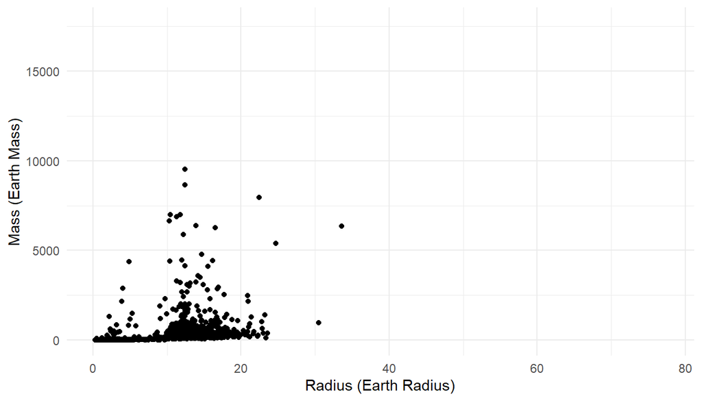

```r
ggplot(planets, aes(radius, mass)) +
  geom_point() +
  xlab("Radius (Earth Radius)") +
  ylab("Mass (Earth Mass)")
```

It’s hard to see any clear pattern in this plot. Let’s adjust the axis scales to see if that helps.

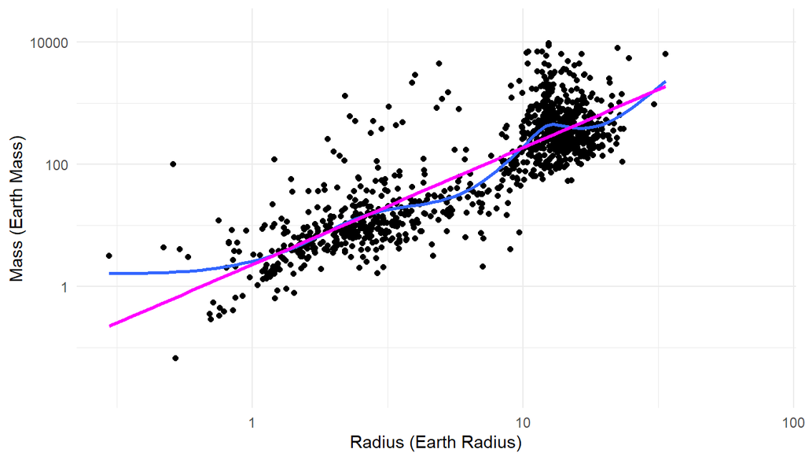

```r
ggplot(planets, aes(radius, mass)) +
  geom_point() +
  xlab("Radius (Earth Radius)") +
  ylab("Mass (Earth Mass)") +
  scale_x_log10() +
  scale_y_log10() +
  geom_smooth(se=FALSE) +
  geom_smooth(method="lm", se=FALSE, color="magenta")
```

Now we can see a bit more of a relationship between mass and radius on this log10 scale.

The *general* pattern is that there is a positive association between log10(radius) and log10(mass).

# Power-Law Relationship

One of the popular models used for the Mass-Radius relationship is a power-law relationship:

$$y = C \times x^\theta$$
where $y$ is the response variable, $x$ is the explanatory variable, $C$ is a scaling factor, and $\theta$ is the power law coefficient.

#### Examples of power laws

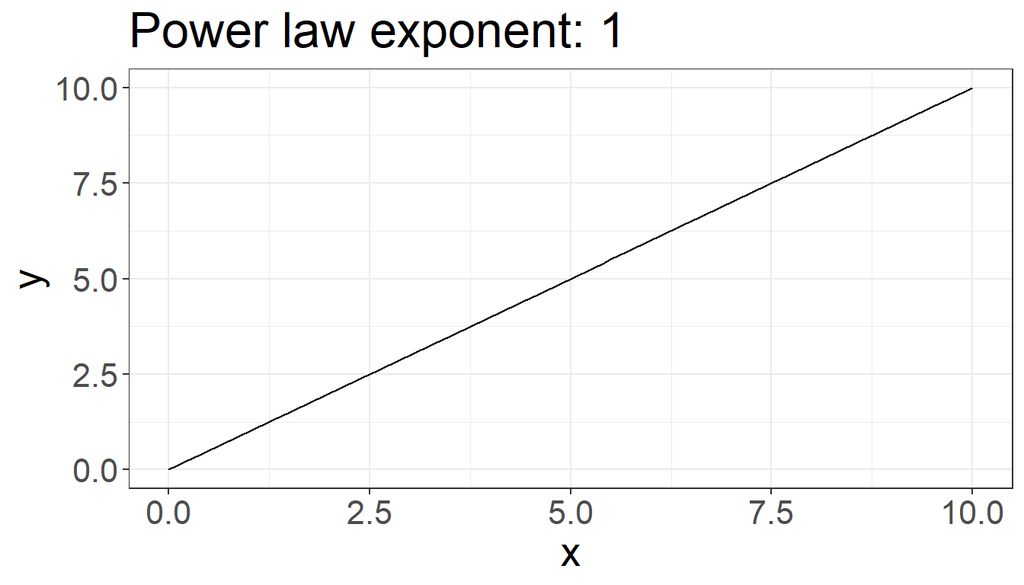

```r
power_law <- function(theta){
  df <- tibble(x = seq(0, 10, by = .1),
               y =x^theta)
  gg <- ggplot(df, aes(x,y)) +
    geom_line() +
    ggtitle(paste0("Power law exponent: ", theta)) +
    theme_bw() +
    theme(text=element_text(size=20))
  return(gg)
}

power_law(1)
```

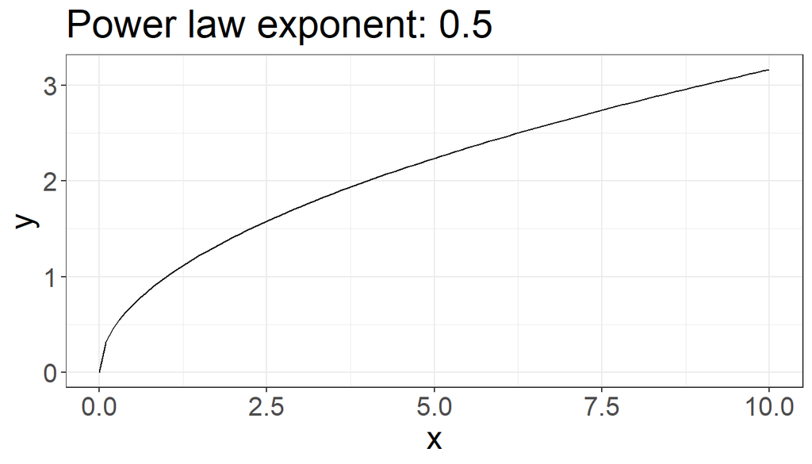

```r
power_law(.5)
```

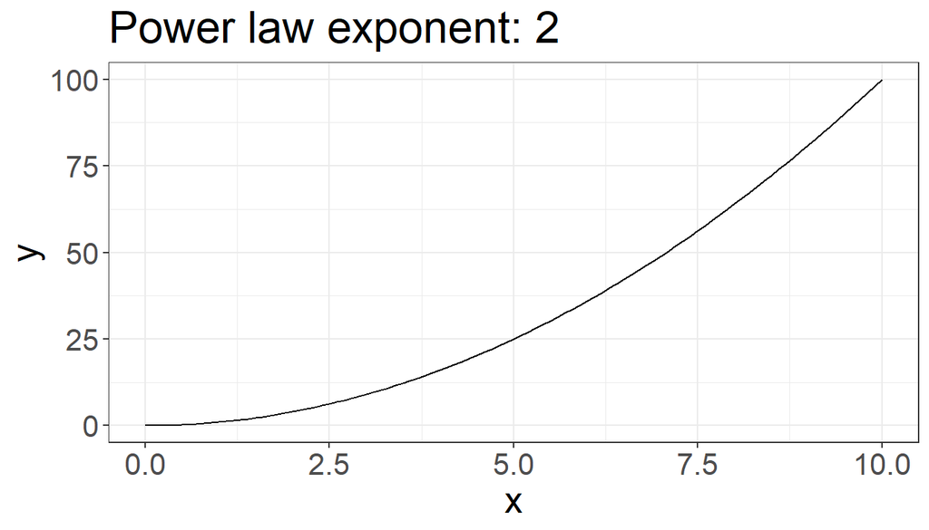

```r
power_law(2)
```

#### Power-law model for Mass-Radius relationship

While we will consider mass on the y-axis and radius on the x-axis, astronomers will often plot and model these the other way (with radius on the y-axis).

- Since the mass measurements tend to be harder to obtain, we can look at our mass vs. radius model as useful for using an estimated radius to predict an unknown mass.

Astronomers have found that the power law relationship between mass and radius is not constant across the range of values, but instead there seems to be a different power law exponent for different mass ranges.

- This results in what is known as a *broken power law model* where different ranges of the data have different power law parameters.
- We will only consider a subset of the data where the power law exponent is thought to be constant. We define this subset below.
- The range for masses we will consider is between 2 and 127 Earth masses. This range comes from work by Jingjing Chen and David Kipping in 2016 where they took a data-driven approach to detect *change points* in the broken power law model.
  - Chen, J. and Kipping, D., 2016. Probabilistic forecasting of the masses and radii of other worlds. The Astrophysical Journal, 834(1), p.17.
  - In their model, they considered radius vs. mass, but found the noted mass range to be consistent with previous work looking for change points in radius.

Below we define the data subset we will use for our model and plot mass vs. radius.

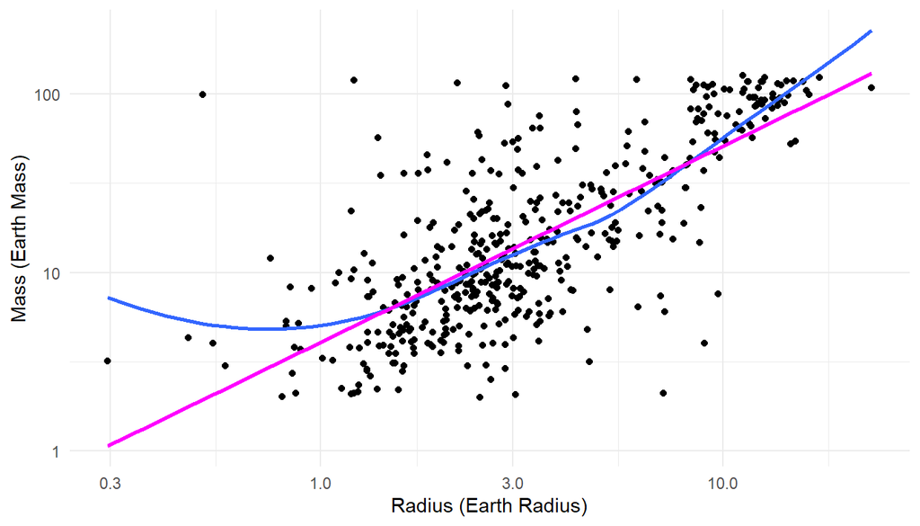

```r
mr <- planets %>%
  filter(between(mass, 2, 127)) %>%
  drop_na()

ggplot(mr, aes(radius, mass)) +
  geom_point() +
  xlab("Radius (Earth Radius)") +
  ylab("Mass (Earth Mass)") +
  scale_x_log10() +
  scale_y_log10() +
  geom_smooth(se=FALSE) +
  geom_smooth(method="lm", se=FALSE, color="magenta")
```

# Fitting the Power Law Model

We already saw the form of the power law relationship is $y = C \times x^\theta$. Now we’d like to turn this into a statistical model that we can use for the exoplanet data.

The statistical model we will actually fit is going to use a log10 transformation of the power law relationship in order to make the form linear:
$$\begin{align*}
y_i = \log10(m_i) & = \log10(C) + \theta\log10(r_i) + \varepsilon_i
\\
& = \log10(C) + \theta x_i + \varepsilon_i, i = 1, \ldots, n.
\end{align*}$$
In this model, the response variable $y_i = \log10(m_i)$ is the $\log10$(mass) for exoplanet $i$, the explanatory variable $x_i = \log10(r_i)$ is the $\log10$(radius) for exoplanet $i$, $\log10(C)$ is the (unknown) intercept, $\theta$ is the (unknown) slope, and $\varepsilon_i$ is the random error for exoplanet $i$.

- Now we have a linear model and can use methods we’ve already learned to fit the model!

```r
lm1 <- lm(log10(mass) ~ log10(radius), data = mr)
summary(lm1)
```

```
##
## Call:
## lm(formula = log10(mass) ~ log10(radius), data = mr)
##
## Residuals:
##      Min       1Q   Median       3Q      Max
## -1.22237 -0.19972 -0.01809  0.17894  1.70979
##
## Coefficients:
##               Estimate Std. Error t value Pr(>|t|)
## (Intercept)    0.60834    0.02913   20.88   <2e-16 ***
## log10(radius)  1.09983    0.04763   23.09   <2e-16 ***
## ---
## Signif. codes:  0 '***' 0.001 '**' 0.01 '*' 0.05 '.' 0.1 ' ' 1
##
## Residual standard error: 0.3297 on 450 degrees of freedom
## Multiple R-squared:  0.5424, Adjusted R-squared:  0.5413
## F-statistic: 533.3 on 1 and 450 DF,  p-value: < 2.2e-16
```

The estimated intercept is 0.608 and the estimated slope is 1.1.

Let’s check out our fit model on a plot:

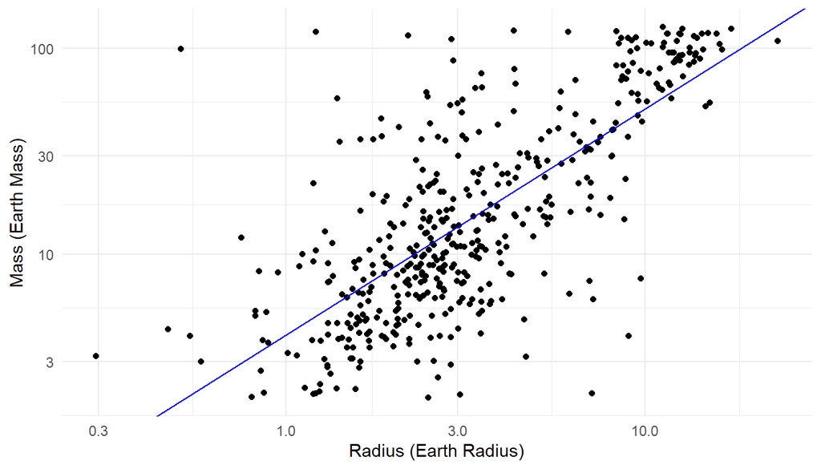

```r
ggplot(mr, aes(radius, mass)) +
  geom_point() +
  xlab("Radius (Earth Radius)") +
  ylab("Mass (Earth Mass)") +
  scale_x_log10() +
  scale_y_log10() +
  geom_abline(aes(slope = coef(lm1)[2] , intercept = coef(lm1)[1]), color="blue")
```

Let’s also see what this looks like on the original scale.

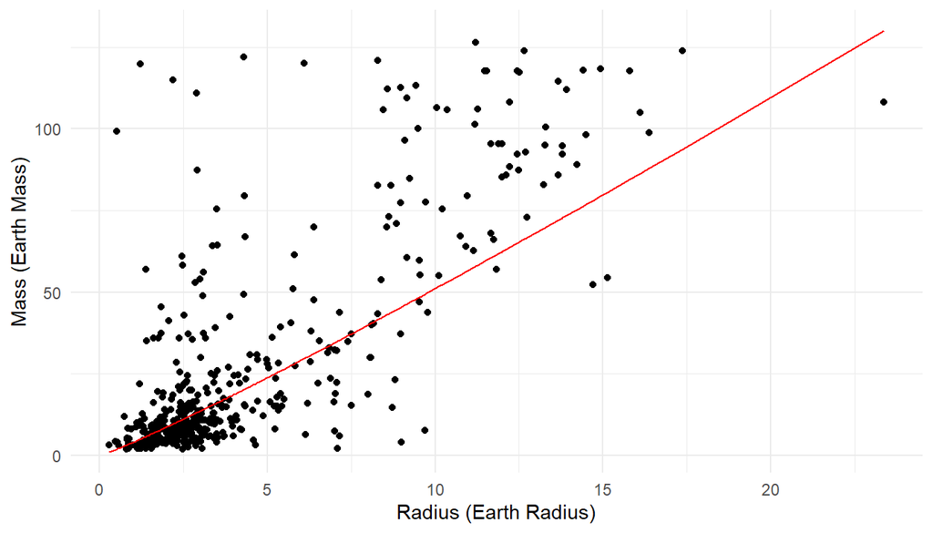

```r
mr %>%
  mutate(mass_pred = 10^coef(lm1)[1]*radius^coef(lm1)[2]) %>%
ggplot(aes(radius, mass)) +
  geom_point() +
  geom_line(aes(y = mass_pred), color="red") +
  xlab("Radius (Earth Radius)") +
  ylab("Mass (Earth Mass)")
```

Recall that the estimated slope is the power law exponent. Since it is somewhat near to 1, this suggests that the data on the original scale are not too far from linear in radius.

- How does our power law model compare to a simple linear regression model fit to our data on the original scale?

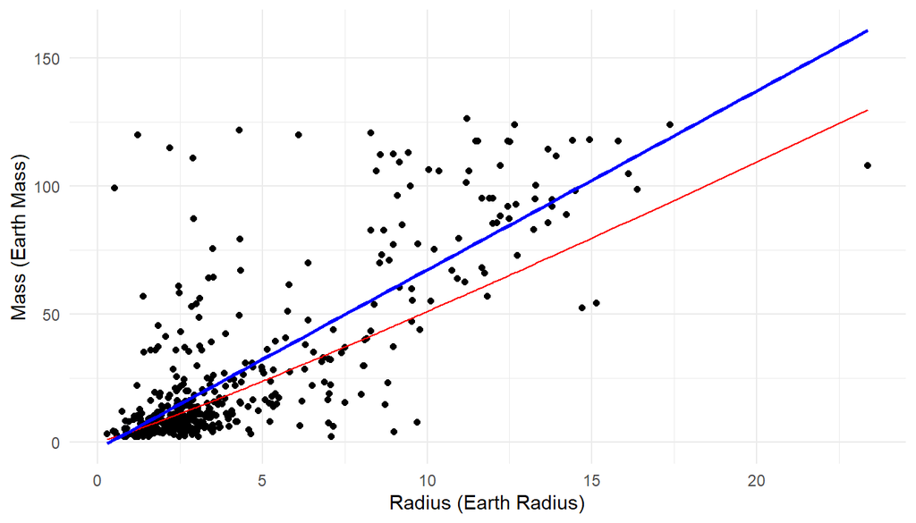

```r
mr %>%
  mutate(mass_pred = 10^coef(lm1)[1]*radius^coef(lm1)[2]) %>%
ggplot(aes(radius, mass)) +
  geom_point() +
  geom_line(aes(y = mass_pred), color="red") +
  xlab("Radius (Earth Radius)") +
  ylab("Mass (Earth Mass)") +
  geom_smooth(method="lm", se=FALSE, color="blue")
```

```r
summary(lm(mass ~ radius, data=mr))
```

```
##
## Call:
## lm(formula = mass ~ radius, data = mr)
##
## Residuals:
##     Min      1Q  Median      3Q     Max
## -57.635  -9.142  -3.917   3.657 114.061
##
## Coefficients:
##             Estimate Std. Error t value Pr(>|t|)
## (Intercept)  -2.6255     1.5123  -1.736   0.0832 .
## radius        6.9959     0.2626  26.637   <2e-16 ***
## ---
## Signif. codes:  0 '***' 0.001 '**' 0.01 '*' 0.05 '.' 0.1 ' ' 1
##
## Residual standard error: 20.67 on 450 degrees of freedom
## Multiple R-squared:  0.6119, Adjusted R-squared:  0.6111
## F-statistic: 709.6 on 1 and 450 DF,  p-value: < 2.2e-16
```

```r
#Back to slides
```

These models are quite different. We will do some model checking on the appropriateness of our linear model on the log10 scale next.

# Model checking

The linear model we fit uses least squares regression.

- This means that the parameters were estimated to minimize the total sum of squared errors.
- Let’s create a plot that displays these errors.

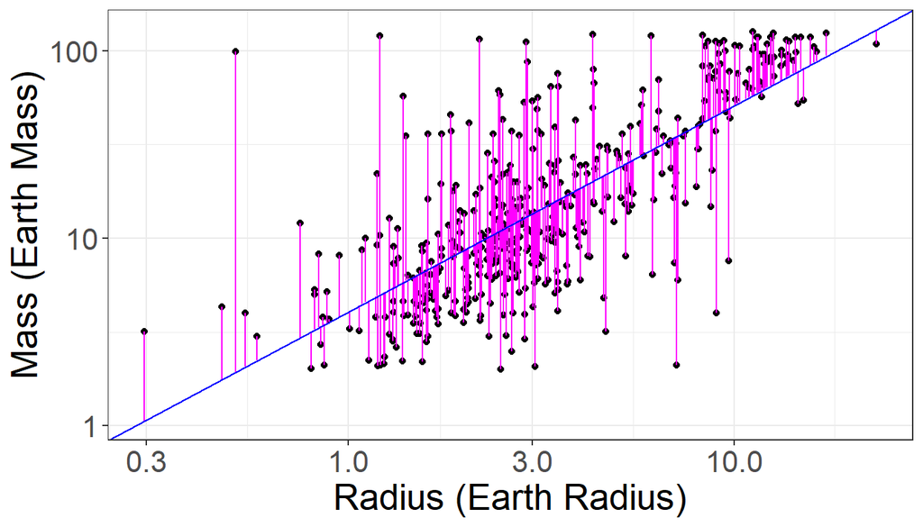

```r
library(modelr)
mr <- mr %>%
  add_residuals(lm1) %>%
  add_predictions(lm1)

ggplot(mr, aes(x=radius, y=mass)) +
  geom_point() +
  geom_segment(aes(xend = radius, yend = 10^pred), color="magenta") +
  xlab("Radius (Earth Radius)") +
  ylab("Mass (Earth Mass)") +
  scale_x_log10() +
  scale_y_log10() +
  geom_abline(aes(slope = coef(lm1)[2] , intercept = coef(lm1)[1]), color="blue") +
    theme_bw() +
    theme(text=element_text(size=20))
```

The vertical magenta bars are the residuals for the model defined as $r_i = y_i - \hat{y}_i$, where $\hat{y}_i$ is the predicted $\log10$(mass) from our model for exoplanet $i$.

### Residual plot

Next we are going to consider a residual plot. This is where we remove the fit model from the data, and only plot the errors (the residuals) against radius.

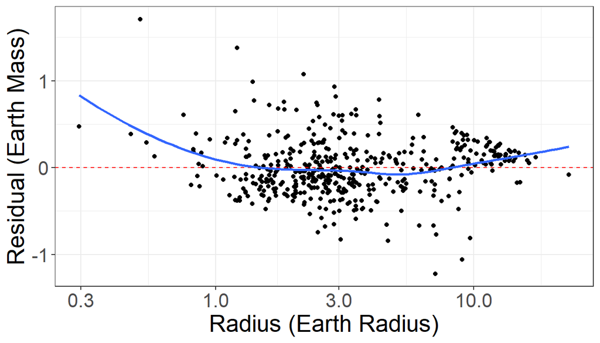

```r
ggplot(mr, aes(x=radius, y=resid)) +
  geom_point() +
  xlab("Radius (Earth Radius)") +
  ylab("Residual (Earth Mass)") +
  scale_x_log10() +
  geom_hline(aes(yintercept = 0), color = "red", linetype = "dashed") +
  theme_bw() +
  theme(text=element_text(size=20)) +
  geom_smooth(se=FALSE)
```

Patterns in a residual plot can suggest that our linear model model may not be appropriate for the data.

- In this case, you may notice that the residuals corresponding to smaller radius values tend to be positive, and there seems to be a little bit of clustering of points (e.g., above 10 Earth Radius).
- But, overall, the model form seems reasonable.

# Introduction to inference on linear models

## Assumptions on the random errors

Let’s go back to our linear model,
$$y_i = \log10(C) + \theta x_i + \varepsilon_i, i = 1, \ldots, n.$$

We only mentioned that the $\varepsilon_i$’s are random errors, but we did not discuss other assumptions.

It is common to make the following assumptions (which should also be checked):

- $E(\varepsilon_i) = 0$.
  - This implies $E(y_i) = \log10(C) + \theta x_i$.
- Errors have a constant variance: Var$(\varepsilon_i) = \sigma^2$.
  - This implies Var$(y_i) = \sigma^2$.
- The errors are uncorrelated.

When desiring to do inference on the estimated parameters, another common assumption to make is that the errors are normally distributed, $\varepsilon_i \sim N(0, \sigma)$.

- This implies that $y_i \sim N(\log10(C) + \theta x_i, \sigma)$.

This normality assumption on the errors has implications for the estimates of our parameters. In particular, it has the consequence that the estimators of our intercept and slope are normally distributed.

## Recall: Z-scores and t-scores

In a previous discussion assignment you were introduced to Z-scores and t-scores. The t-scores are going to show in our regression inference, so we review that information here.

> Note that in this review, the estimator is the sample mean. When we get back to regression the estimators will be for the slope or intercept, which will result in some changes in the t-statistic and the degrees of freedom of the resulting t-distribution.

Assume a model where $X_1,\ldots,X_n$ are drawn at random from a distribution with a mean $\mu$ and a standard deviation $\sigma$.

The sampling distribution of the sample mean, $\bar{X} = n^{-1}\sum_{i=1}^n X_i$ has a mean $\mu$ and standard deviation $\sigma/\sqrt{n}$.

A mathematical derivation is required to show this formally, or simulation can be used to check if it the expressions are plausible.

#### Z-Score

We have seen in many settings that the z-statistic (substract the mean, divide by the standard deviation) often has an approximate standard normal distribution.
$$Z = \frac{\bar{X} - \mu}{\sigma/\sqrt{n}}$$
If the distribution of each $X_i$ is normal, then $Z$ will be normal as well.

Even if $X_i$ does not have a normal distribution, the distribution of $\bar{X}$ will be approximately normal if $n$ is large enough to overcome the non-normality, a result known as the central limit theorem.

#### t distribution

However, $\sigma$ is typically unknown and things are a bit different when the sample standard deviation $s$ is substituted for $\sigma$.
$$T = \frac{\bar{X} - \mu}{S/\sqrt{n}}$$
where
$$S = \sqrt{ \frac{\sum_{i=1}^n (X_i - \bar{X})^2}{n-1} }$$

The added random variability in the denominator means that even when the distribution of a single random variable is exactly normal, the distribution of $T$ is not.

Instead, it has a $t$ distribution with $n-1$ degrees of freedom, which is a bell-shaped density centered at zero, but more spread out than a standard normal density.

When the degrees of freedom becomes large, the $t$ distribution is quite close to standard normal.

It is identical to standard normal when the degrees of freedom is infinite.

#### R functions

These R functions are similar to their normal counterparts.

- `rt()`: generate random variables from a t distribution
- `pt()`: find an area under a t density
- `qt()`: find a quantile from a t density
- `dt()`: return the height of the t density

In addition, the following functions are available in the script ggprob.R to add t densities to plots.

- `geom_t_density()`: add a t density to a plot
- `geom_t_fill()`: add a filled t density
- `gt():` graph a t density

The following graph shows a standard normal distribution in black and t distributions with degrees of freedom equal to 1, 2, 4, 8, , 1028 ranging from yellow to violet.

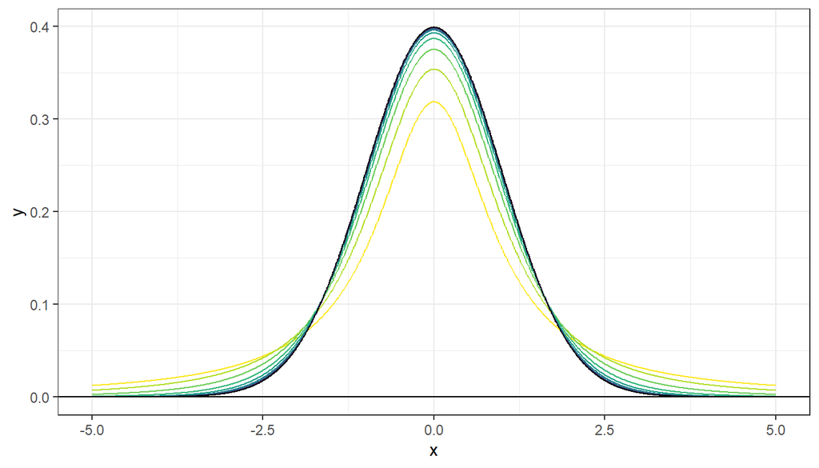

#### Confidence Intervals

A confidence interval for $\mu$ has the form
$$\bar{x} \pm t^* \frac{s}{\sqrt{n}}$$
where $t^*$ is selected so that the area between $-t^*$ and $t^*$ under a t density with $n-1$ degrees of freedom is the desired confidence level.

A confidence interval for a difference between means, $\mu_1 - \mu_2$, has the form
$$\bar{x}_1 - \bar{x}_2 \pm t^*
\sqrt{ \frac{s_1^2}{n_1} + \frac{s_2^2}{n_2} }$$
where $t^*$ is from a $t$ distribution where the degrees of freedom is estimated as a function of the sample sizes and standard deviations. Use the function `t.test()`. This approach assumes that the standard deviations of the two populations need not be the same.

#### Hypothesis Tests

When using t distribution methods, p-values are found by calculating the t statistic and finding areas under t distributions.

## Back to regression

These concepts will be used to carry out inference on the estimated parameters of our simple linear model, which we will do next.

# Inference for linear models

If we make the assumption that the errors on linear model are normally distributed, we can carryout hypothesis test on our estimated parameters.

We will focus on inference for the slope parameter since that tends to be the more scientifically interesting parameter.

The hypothesis test we will carry out is
$$H_0: \theta = 1 \\
H_a: \theta \neq 1$$

This leads to the test statistic
$$T = \frac{\hat{\theta} - 1}{s_{\hat{\theta}}}$$
where $s_{\hat{\theta}}$ is the standard error of $\hat{\theta}$. Note that the 1 is from the null hypothesis assumption that $\theta = 1$.

- In case you were curious, the formula for this standard error is
  $$s_{\hat{\theta}} = \sqrt{\frac{\sum_{i = 1}^n (y_i -
  \hat{y}_i)^2/(n-2)}{\sum_{i = 1}^n (x_i - \overline{x})^2}}$$
  where $\overline{x}$ is the sample mean of the $x_i$, and $\hat{y}_i$ is the predicted $\log10$(mass) values for observation $i$.
- We can calculate this as follows:

```r
n <- nrow(mr)
syy <- sum(mr$resid^2)
sxx <- sum((log10(mr$radius) - mean(log10(mr$radius)))^2)
sqrt(syy/(n-2)/sxx)  ## standard error using the formula above
```

```
## [1] 0.04762569
```

```r
coef(summary(lm1))[2, "Std. Error"] ## standard error from our lm1 model
```

```
## [1] 0.04762569
```

This is also the standard error that would be used in a confidence interval for $\theta$: $\hat{\theta} \pm t_{n-2} s_{\hat{\theta}}$, where $t_{n-2}$ is selected based on the desired confidence level.

- You may be wondering why we have a $t$ distribution with $n-2$ degrees of freedom here. This is because our model has two parameters (the slope and intercept) so we “use up” two degrees of freedom when estimating them.

The output of our estimated model gives us the result of (a different) hypothesis test:
$$H_0: \theta = 0 \\
H_a: \theta \neq 0$$

```r
summary(lm1)
```

```
##
## Call:
## lm(formula = log10(mass) ~ log10(radius), data = mr)
##
## Residuals:
##      Min       1Q   Median       3Q      Max
## -1.22237 -0.19972 -0.01809  0.17894  1.70979
##
## Coefficients:
##               Estimate Std. Error t value Pr(>|t|)
## (Intercept)    0.60834    0.02913   20.88   <2e-16 ***
## log10(radius)  1.09983    0.04763   23.09   <2e-16 ***
## ---
## Signif. codes:  0 '***' 0.001 '**' 0.01 '*' 0.05 '.' 0.1 ' ' 1
##
## Residual standard error: 0.3297 on 450 degrees of freedom
## Multiple R-squared:  0.5424, Adjusted R-squared:  0.5413
## F-statistic: 533.3 on 1 and 450 DF,  p-value: < 2.2e-16
```

```r
## Number of observations
mr %>%
  nrow()
```

```
## [1] 452
```

```r
## Compute our p-value
pt(22.08, df=366, lower.tail=FALSE)*2 ## P(T >= 22.08) x 2
```

```
## [1] 2.785903e-69
```

Notice that this p-value is very small leading us to reject the null hypothesis that the slope is zero.

```r
## t-statistic
tstat <- (coef(summary(lm1))[2]-1)/coef(summary(lm1))[2, "Std. Error"]
tstat
```

```
## [1] 2.096235
```

```r
## Compute our p-value
pt(tstat, df=nrow(mr)-2, lower.tail=FALSE)*2 ## P(T >= 2.425118) x 2
```

```
## [1] 0.03661927
```

We can create a plot to visualize the p-value:

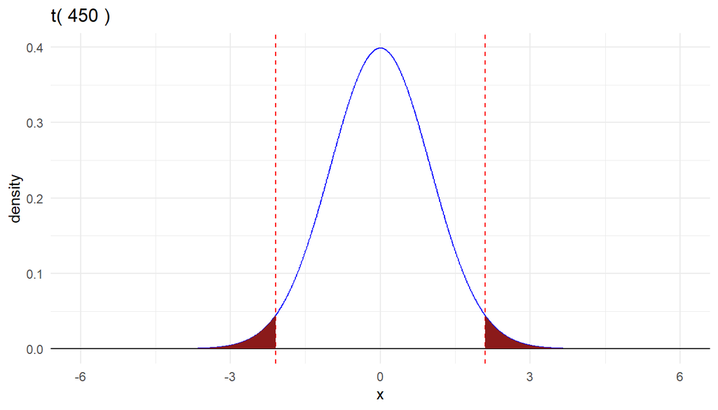

```r
gt(nrow(mr)-2) +
  geom_vline(aes(xintercept = c(-abs(tstat), tstat)), color="red", linetype="dashed") +
  geom_t_fill(nrow(mr)-2, a = abs(tstat), b=6) +
  geom_t_fill(nrow(mr)-2, a=-6, b = -abs(tstat))
```

# Inference for linear models via simulation

Instead of relying on the theoretical values for the standard deviation of the parameters, we could instead run a simulation.

We can use the parametric bootstrap, which involves generating many realizations of the data using the initial estimate for $\theta$ and then fitting the regression model on the simulated data set to obtain many estimates of $\theta$. The mean and standard deviation of these values can be used for inference.

Here are the steps for the parametric bootstrap:

1. Estimate the parameters of the statistical model.
2. Use the estimated model and simulate a new data set of the same size.
   - In a regression framework, this would involve adding to each predicted value $y^*$ a new simulated normally distributed random error from a distribution with mean zero and the estimated standard deviation.
3. Fit a linear model to the simulated data set and estimate the coefficients.
4. Repeat steps 2 and 3 many times.
5. Calculate the standard deviations of the coefficients from the simulated data sets as estimates of the standard errors.

```r
n <- mr %>%
  select(mass, radius) %>%
  drop_na() %>%
  nrow()
sigma_resid <- sd(mr$resid)
N <- 100 # 10000
b_0 <- numeric(N)
b_1 <- numeric(N)

for ( i in 1:N )
{
  mr_new <- mr %>%
    drop_na() %>%
    mutate(mass = 10^(pred + rnorm(n,0,sigma_resid))) # these are the "new" y's
  lm2 <- lm(log10(mass) ~ log10(radius), data=mr_new)
  b_0[i] <- coef(lm2)[1]
  b_1[i] <- coef(lm2)[2]
}

df_coef <- tibble(b_0,b_1)
```

Let’s look at the slope parameter. We can estimate the mean and standard deviation from the parametric bootstrap simulation, and then compare it to a normal distribution with the same mean and standard deviation.

```r
mean_slope <- mean(df_coef$b_1)
mean_slope
```

```
## [1] 1.109346
```

```r
sd_slope <- sd(df_coef$b_1)
sd_slope
```

```
## [1] 0.05257524
```

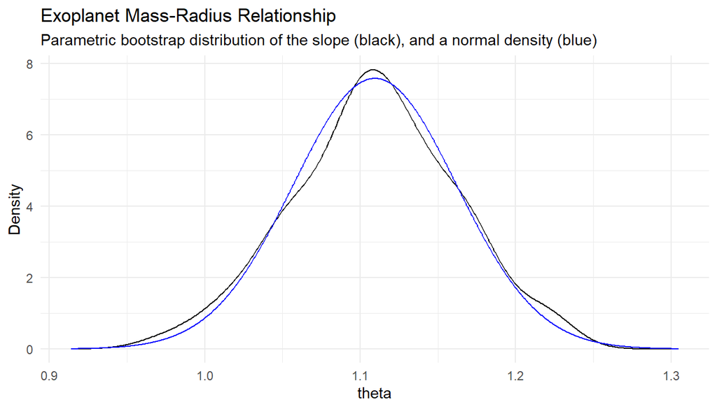

```r
ggplot(df_coef, aes(x=b_1)) +
  geom_density() +
  xlab("theta") +
  ylab("Density") +
  geom_norm_density(mu = mean_slope, sigma = sd_slope, color="blue") +
  ggtitle("Exoplanet Mass-Radius Relationship",
          subtitle = "Parametric bootstrap distribution of the slope (black), and a normal density (blue)")
```

The simulated distribution (black curve) follows the normal distribution (blue curve) quite well.

So how do these values compare to what we calculated with the theoretical equations?

```r
paste("Bootstrap: ", round(mean_slope,3), round(sd_slope,3))
```

```
## [1] "Bootstrap:  1.109 0.053"
```

```r
paste("Theoretical: ", round(coef(lm1)[2],3), round(coef(summary(lm1))[2, "Std. Error"],3))
```

```
## [1] "Theoretical:  1.1 0.048"
```

Very close as well!

# Prediction

### Recall: Mass-Radius Relationship

The *mass-radius relationship* of exoplanets is the relationship between exoplanets’ radius, R, their mass, M.

Modeling the relationship between mass and radius is important for the following reasons:

- Prediction
  - The model can be used to predict a planet’s mass given its radius measurement
  - We have more observations with radius estimates than mass estimates, so having a way to estimate mass can be useful

```r
## Number of mass and radius estimates
planets %>%
  select(mass, radius) %>%
  summarize_all(function(x) sum(!is.na(x)))
```

```
## # A tibble: 1 × 2
##    mass radius
##   <int>  <int>
## 1  2144   3926
```

- Learning about exoplanets compositions
  - Planet compositions can be inferred by their density
  - Exoplanets can have a range of compositions such as rocky or gaseous
  - Knowing about planet composition may help to understand planetary formation and evolution processes
  - For more information about planet compositions, see [exoplanet compositions](http://astro140.courses.science.psu.edu/theme4/census-and-properties-of-exoplanets/exoplanet-composition/)

#### Plot Mass vs. Radius - quick look

Let’s take a quick look at what the Mass-Radius relationship looks like for our exoplanet data. We’ll talk later about a way to model these data.

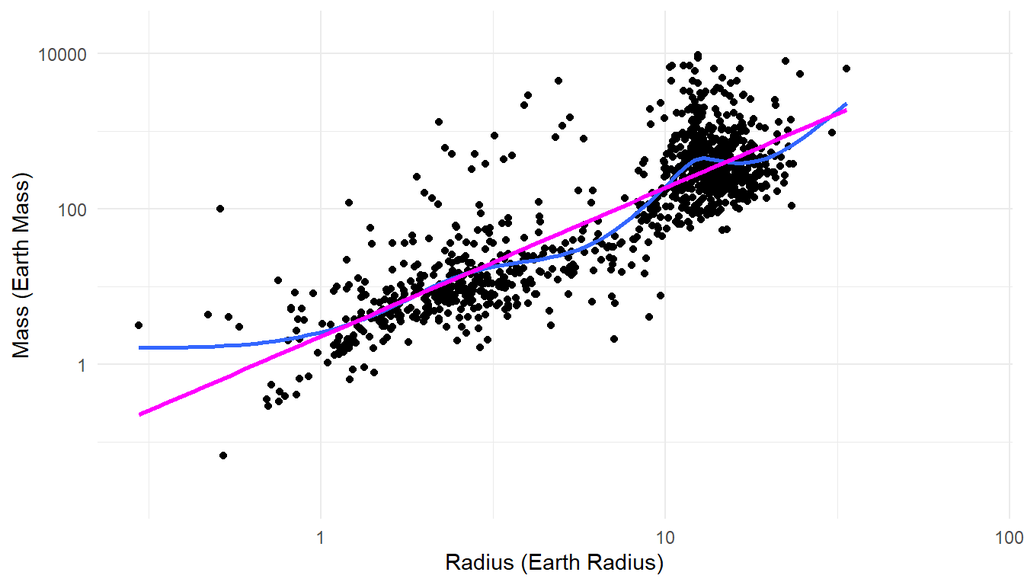

```r
ggplot(planets, aes(radius, mass)) +
  geom_point() +
  xlab("Radius (Earth Radius)") +
  ylab("Mass (Earth Mass)") +
  scale_x_log10() +
  scale_y_log10() +
  geom_smooth(se=FALSE) +
  geom_smooth(method="lm", se=FALSE, color="magenta")
```

The *general* pattern is that there is a positive association between log10(radius) and log10(mass).

#### Recall: Power-law model for Mass-Radius relationship

While we will consider mass on the y-axis and radius on the x-axis, astronomers will often plot and model these the other way (with radius on the y-axis).

- Since the mass measurements tend to be harder to obtain, we can look at our mass vs. radius model as useful for using an estimated radius to predict an unknown mass.

Astronomers have found that the power law relationship between mass and radius is not constant across the range of values, but instead there seems to be a different power law exponent for different mass ranges.

- This results in what is known as a *broken power law model* where different ranges of the data have different power law parameters.
- We will only consider a subset of the data where the power law exoponent is thought to be constant. We define this subset below.
- The range for masses we will consider is between 2 and 127 Earth masses. This range comes from work by Jingjing Chen and David Kipping in 2016 where they took a data-driven approach to detect *change points* in the broken power law model.
  - Chen, J. and Kipping, D., 2016. Probabilistic forecasting of the masses and radii of other worlds. The Astrophysical Journal, 834(1), p.17.
  - In their model, they considered radius vs. mass, but found the noted mass range to be consistent with previous work looking for change points in radius.

Below we define the data subset we will use for our model and plot mass vs. radius.

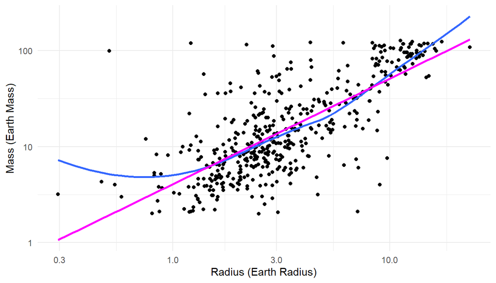

```r
mr <- planets %>%
  filter(between(mass, 2, 127)) %>%
  drop_na()

ggplot(mr, aes(radius, mass)) +
  geom_point() +
  xlab("Radius (Earth Radius)") +
  ylab("Mass (Earth Mass)") +
  scale_x_log10() +
  scale_y_log10() +
  geom_smooth(se=FALSE) +
  geom_smooth(method="lm", se=FALSE, color="magenta")
```